# Predicting bike rentals with linear and random forest regression

2024-06-23

```r
rm(list=ls())
```

### Libraries

```r
library(tidyverse)
library(caret)
library(scales)
library(MLmetrics)
library(lubridate)
library(scales)
library(olsrr)
library(car)
library(randomForest)
library(fastDummies)
library(janitor)
```

## Reading and cleaning the data

```r
df <- read.csv('bikes.csv')
```

### Recoding variables

```r
df <- df %>%
  mutate_if(is.integer,as.character) %>%
  mutate(weather = dplyr::recode(weather, "1" = "Clear_or_partly_cloudy", "2" = "Light_precipitation", "3" ="Heavy_precipitation")) %>%
  mutate(season = dplyr::recode(season, "1" = "Winter", "2" = "Spring", "3" = "Summer", "4" ="Fall")) %>%
  mutate(holiday = dplyr::recode(holiday, "0" = "No", "1" = "Yes")) %>%
  mutate(weekday = dplyr::recode(weekday, "0" = "Sunday", "1" = "Monday", "2" = "Tuesday", "3" = "Wednesday",
                                 "4" = "Thursday", "5" = "Friday", "6" = "Saturday", "7" = "Sunday")) %>%
  mutate(date = lubridate::ymd(date)) %>%
  mutate_at(c(2:5),as.factor) %>%
  mutate(rentals = as.numeric(rentals))
```

```r
head(df)
```

```
##         date season holiday   weekday                weather temperature
## 1 2011-01-01 Winter      No  Saturday    Light_precipitation    46.71653
## 2 2011-01-02 Winter      No    Sunday    Light_precipitation    48.35024
## 3 2011-01-03 Winter      No    Monday Clear_or_partly_cloudy    34.21239
## 4 2011-01-04 Winter      No   Tuesday Clear_or_partly_cloudy    34.52000
## 5 2011-01-05 Winter      No Wednesday Clear_or_partly_cloudy    36.80056
## 6 2011-01-06 Winter      No  Thursday Clear_or_partly_cloudy    34.88784
##   realfeel humidity windspeed rentals
## 1 46.39865 0.805833  6.679665     985
## 2 45.22419 0.696087 10.347140     801
## 3 25.70131 0.437273 10.337565    1349
## 4 28.40009 0.590435  6.673420    1562
## 5 30.43728 0.436957  7.780994    1600
## 6 30.90523 0.518261  3.728766    1606
```

```r
df <- df %>%
  mutate_if(is.numeric,~round(.x,2))
```

## Exploratory analysis

### Relationship between bike rentals and other numeric variables

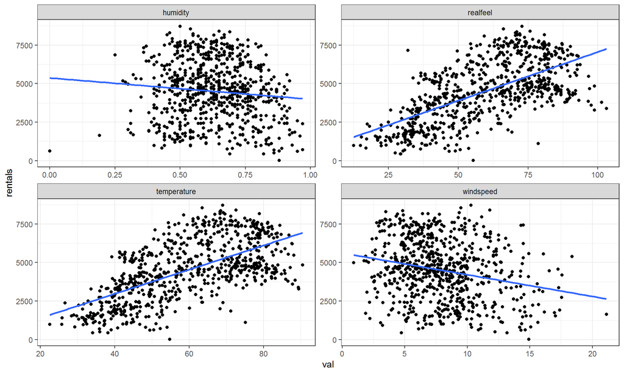

```r
df %>%
  gather(c(6:9),key="key",value="val") %>%
  select(c(6:8)) %>%
  ggplot(aes(x=val,y=rentals)) +
  geom_point() +
  geom_smooth(method="lm",se=F)+
  facet_wrap(~key,scales="free") +
   theme_bw()
```

### Correlation between bike rentals and other numeric variables

```r
cor(df$rentals,df$temperature)
```

```
## [1] 0.6274882
```

```r
cor(df$rentals,df$realfeel)
```

```
## [1] 0.6310589
```

```r
cor(df$rentals,df$windspeed)
```

```
## [1] -0.2345758
```

```r
cor(df$rentals,df$humidity)
```

```
## [1] -0.101715
```

```r
df <- df %>%
  mutate(season = factor(season, levels = c("Spring", "Summer", "Fall", "Winter")))
```

### Sum of bike rentals by season

```r
df_group_season <- df %>%
  group_by(season) %>%
  summarise(sum_rentals = sum(rentals))
```

```r
df_group_season
```

```
## # A tibble: 4 x 2
##   season sum_rentals
##   <fct>        <dbl>
## 1 Spring      918589
## 2 Summer     1061129
## 3 Fall        841613
## 4 Winter      471348
```

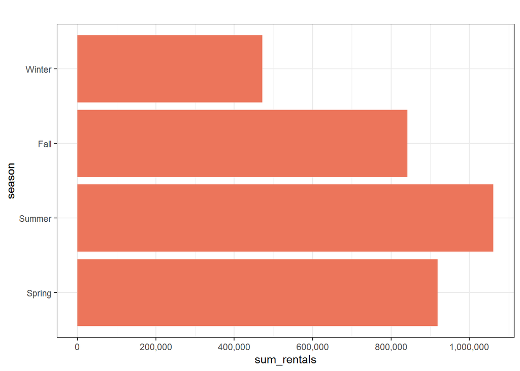

```r
df_group_season %>%
  ggplot(aes(x=season,y=sum_rentals)) +
  geom_bar(stat="identity",fill="#EC755B") +
  labs(title="") +
  scale_y_continuous(label=comma, breaks = seq(0,1000000,200000))+
  coord_flip() +
  theme_bw()
```

##### The most bikes were rented during summer and the least during witner. It could be anticipated based on the positive linear relation between temperature and bike rentals

```r
df <- df %>%
  mutate(weekday = factor(weekday, levels = c("Monday","Tuesday","Wednesday","Thursday", "Friday", "Saturday", "Sunday")))
```

### Bike rentals by weekday

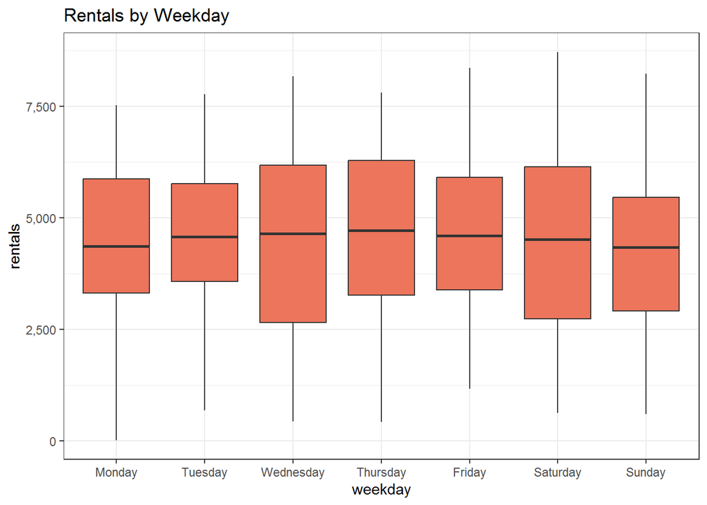

```r
df %>%
  ggplot(aes(x=weekday,y=rentals)) +
  geom_boxplot(fill="#EC755B") +
  scale_y_continuous(labels = scales::comma) +
  labs(title="Rentals by Weekday") +
  theme_bw()
```

##### There doesn’t seem to be any clear pattern. All of the medians are very close to each other.

### Bike rentals by weather type

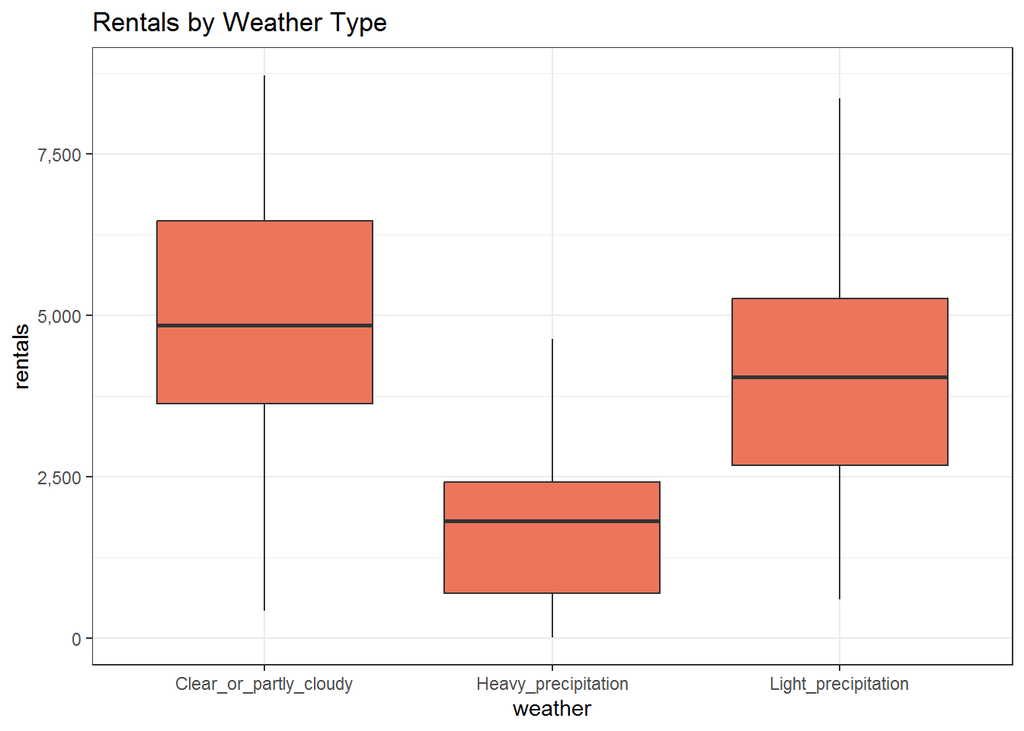

```r
df %>%
  ggplot(aes(x=weather,y=rentals)) +
  geom_boxplot(fill="#EC755B") +
  scale_y_continuous(labels = scales::comma) +
  labs(title="Rentals by Weather Type") +
  theme_bw()
```

##### There is a clear pattern. People tend to rent bikes when the weather is good

```r
df <- df %>%
  select(-c(1))
```

## Modeling

### Data partition

```r
set.seed(123)

data_partition <- caret::createDataPartition(df$rentals, p = 0.6, list = F)

train_set <- df[data_partition,]
test_set <- df[-data_partition,]

print(nrow(train_set))
```

```
## [1] 440
```

```r
print(nrow(test_set))
```

```
## [1] 291
```

```r
print(nrow(train_set)/nrow(df))
```

```
## [1] 0.6019152
```

```r
head(train_set)
```

```
##    season holiday   weekday                weather temperature realfeel
## 4  Winter      No   Tuesday Clear_or_partly_cloudy       34.52    28.40
## 6  Winter      No  Thursday Clear_or_partly_cloudy       34.89    30.91
## 7  Winter      No    Friday    Light_precipitation       34.23    28.01
## 8  Winter      No  Saturday    Light_precipitation       31.56    22.48
## 12 Winter      No Wednesday Clear_or_partly_cloudy       32.21    22.26
## 13 Winter      No  Thursday Clear_or_partly_cloudy       31.56    21.12
##    humidity windspeed rentals
## 4      0.59      6.67    1562
## 6      0.52      3.73    1606
## 7      0.50      7.02    1510
## 8      0.54     11.11     959
## 12     0.60     12.68    1162
## 13     0.47     12.53    1406
```

### First linear model

```r
lm_mod <- lm(formula = rentals ~., data = train_set)
```

```r
summary(lm_mod)
```

```
##
## Call:
## lm(formula = rentals ~ ., data = train_set)
##
## Residuals:
##     Min      1Q  Median      3Q     Max
## -3647.3  -938.8  -244.9  1038.3  3829.9
##
## Coefficients:
##                              Estimate Std. Error t value Pr(>|t|)
## (Intercept)                 1669.1535   674.4587   2.475  0.01372 *
## seasonSummer                -533.5342   204.5702  -2.608  0.00943 **
## seasonFall                   480.9910   190.4876   2.525  0.01193 *
## seasonWinter                -683.9247   227.4326  -3.007  0.00279 **
## holidayYes                  -653.9488   387.7500  -1.687  0.09243 .
## weekdayTuesday               120.9477   231.0479   0.523  0.60092
## weekdayWednesday             149.4186   242.1786   0.617  0.53758
## weekdayThursday               75.1179   241.5200   0.311  0.75594
## weekdayFriday                227.5344   244.5576   0.930  0.35270
## weekdaySaturday              142.8165   237.3867   0.602  0.54775
## weekdaySunday               -136.4164   233.6591  -0.584  0.55965
## weatherHeavy_precipitation -2355.7723   419.5134  -5.615 3.56e-08 ***
## weatherLight_precipitation  -317.1057   164.8639  -1.923  0.05510 .
## temperature                   77.9697    28.9026   2.698  0.00726 **
## realfeel                       0.1666    22.2947   0.007  0.99404
## humidity                   -1751.4010   586.1032  -2.988  0.00297 **
## windspeed                    -53.8600    21.2558  -2.534  0.01164 *
## ---
## Signif. codes:  0 '***' 0.001 '**' 0.01 '*' 0.05 '.' 0.1 ' ' 1
##
## Residual standard error: 1303 on 423 degrees of freedom
## Multiple R-squared:  0.559,  Adjusted R-squared:  0.5423
## F-statistic: 33.51 on 16 and 423 DF,  p-value: < 2.2e-16
```

##### Some variables are not statistically significant. As it was noted before, the weekday variable doesn’t seem to add anything to the model. Moreover, there most likely exists some collinearity because variables temperature and realfeel are based on each other. It’s also seen in the variance inflation rate values that exceed 5.0 for both of these variables

### Variance inflation rate

```r
vif(lm_mod)
```

```
##                  GVIF Df GVIF^(1/(2*Df))
## season       3.439678  3        1.228626
## holiday      1.117967  1        1.057340
## weekday      1.216851  6        1.016490
## weather      1.797256  2        1.157851
## temperature 53.030817  1        7.282226
## realfeel    49.432081  1        7.030795
## humidity     1.820858  1        1.349392
## windspeed    1.202493  1        1.096582
```

### Durbin Watson test

```r
car::durbinWatsonTest(lm_mod)
```

```
##  lag Autocorrelation D-W Statistic p-value
##    1       0.7220176      0.554628       0
##  Alternative hypothesis: rho != 0
```

### Second linear model

##### This model was evaluated with the usage of the stepwise backward regression

```r
lm_mod_backward_p <- olsrr::ols_step_backward_p(model = lm(formula = rentals ~., data = train_set),prem = 0.1,progress = F)
```

```r
lm_mod_backward_p$metrics
```

```
##   step variable        r2    adj_r2      aic      sbc     sbic mallows_cp
## 1    1 realfeel 0.5589667 0.5433641 7576.763 7646.238 6312.737  15.000056
## 2    2  weekday 0.5556385 0.5463379 7568.071 7613.025 6313.856   6.192145
##       rmse
## 1 1277.146
## 2 1281.956
```

##### The variables above were deleted from the model based on their p-value

```r
lm_mod_backward_p
```

```
##
##
##                                Stepwise Summary
## ----------------------------------------------------------------------------
## Step    Variable        AIC         SBC         SBIC        R2       Adj. R2
## ----------------------------------------------------------------------------
##  0      Full Model    7578.763    7652.325    6314.817    0.55897    0.54228
##  1      realfeel      7576.763    7646.238    6312.737    0.55897    0.54336
##  2      weekday       7568.071    7613.025    6313.856    0.55564    0.54634
## ----------------------------------------------------------------------------
##
## Final Model Output
## ------------------
##
##                             Model Summary
## ----------------------------------------------------------------------
## R                          0.745       RMSE                  1281.956
## R-Squared                  0.556       MSE                1681629.050
## Adj. R-Squared             0.546       Coef. Var               28.891
## Pred R-Squared             0.534       AIC                   7568.071
## MAE                     1099.700       SBC                   7613.025
## ----------------------------------------------------------------------
##  RMSE: Root Mean Square Error
##  MSE: Mean Square Error
##  MAE: Mean Absolute Error
##  AIC: Akaike Information Criteria
##  SBC: Schwarz Bayesian Criteria
##
##                                     ANOVA
## -----------------------------------------------------------------------------
##                       Sum of
##                      Squares         DF      Mean Square      F         Sig.
## -----------------------------------------------------------------------------
## Regression     904179412.054          9    100464379.117    59.742    0.0000
## Residual       723100491.434        430      1681629.050
## Total         1627279903.489        439
## -----------------------------------------------------------------------------
##
##                                               Parameter Estimates
## ----------------------------------------------------------------------------------------------------------------
##                      model         Beta    Std. Error    Std. Beta      t        Sig         lower        upper
## ----------------------------------------------------------------------------------------------------------------
##                (Intercept)     1736.019       572.488                  3.032    0.003      610.796     2861.243
##               seasonSummer     -516.007       200.723       -0.115    -2.571    0.010     -910.528     -121.487
##                 seasonFall      483.633       189.045        0.108     2.558    0.011      112.065      855.201
##               seasonWinter     -681.613       225.286       -0.152    -3.026    0.003    -1124.411     -238.814
##                 holidayYes     -712.020       366.640       -0.063    -1.942    0.053    -1432.650        8.610
## weatherHeavy_precipitation    -2331.801       413.255       -0.205    -5.643    0.000    -3144.053    -1519.549
## weatherLight_precipitation     -295.549       163.521       -0.072    -1.807    0.071     -616.950       25.852
##                temperature       78.205         7.103        0.636    11.010    0.000       64.245       92.166
##                   humidity    -1767.316       580.459       -0.131    -3.045    0.002    -2908.205     -626.427
##                  windspeed      -53.165        20.805       -0.089    -2.555    0.011      -94.058      -12.272
## ----------------------------------------------------------------------------------------------------------------
```

##### The second model exhibits slighly higher adjusted R^2 and it’s also less complicated

##### The second model was transformed to the lm variable because it’s easier to analyze such datatype

```r
lm_mod_backward_p <- lm(formula = rentals ~. -realfeel -weekday, data = train_set)
```

```r
summary(lm_mod_backward_p)
```

```
##
## Call:
## lm(formula = rentals ~ . - realfeel - weekday, data = train_set)
##
## Residuals:
##     Min      1Q  Median      3Q     Max
## -3502.6  -913.5  -266.1  1111.6  3887.1
##
## Coefficients:
##                             Estimate Std. Error t value Pr(>|t|)
## (Intercept)                 1736.019    572.488   3.032  0.00257 **
## seasonSummer                -516.007    200.723  -2.571  0.01048 *
## seasonFall                   483.633    189.045   2.558  0.01086 *
## seasonWinter                -681.613    225.286  -3.026  0.00263 **
## holidayYes                  -712.020    366.640  -1.942  0.05279 .
## weatherHeavy_precipitation -2331.801    413.255  -5.643 3.04e-08 ***
## weatherLight_precipitation  -295.549    163.521  -1.807  0.07140 .
## temperature                   78.205      7.103  11.010  < 2e-16 ***
## humidity                   -1767.316    580.459  -3.045  0.00247 **
## windspeed                    -53.165     20.805  -2.555  0.01095 *
## ---
## Signif. codes:  0 '***' 0.001 '**' 0.01 '*' 0.05 '.' 0.1 ' ' 1
##
## Residual standard error: 1297 on 430 degrees of freedom
## Multiple R-squared:  0.5556, Adjusted R-squared:  0.5463
## F-statistic: 59.74 on 9 and 430 DF,  p-value: < 2.2e-16
```

### Variance inflation rate

```r
vif(lm_mod_backward_p)
```

```
##                 GVIF Df GVIF^(1/(2*Df))
## season      3.270935  3        1.218368
## holiday     1.008484  1        1.004233
## weather     1.739719  2        1.148470
## temperature 3.231272  1        1.797574
## humidity    1.801911  1        1.342353
## windspeed   1.162367  1        1.078131
```

##### None of the values exceed 5.0 indicating that there is no collinearity between variables

### Durbin Waton test

```r
car::durbinWatsonTest(lm_mod_backward_p)
```

```
##  lag Autocorrelation D-W Statistic p-value
##    1        0.714462     0.5695198       0
##  Alternative hypothesis: rho != 0
```

### Residual vs fitted values plot

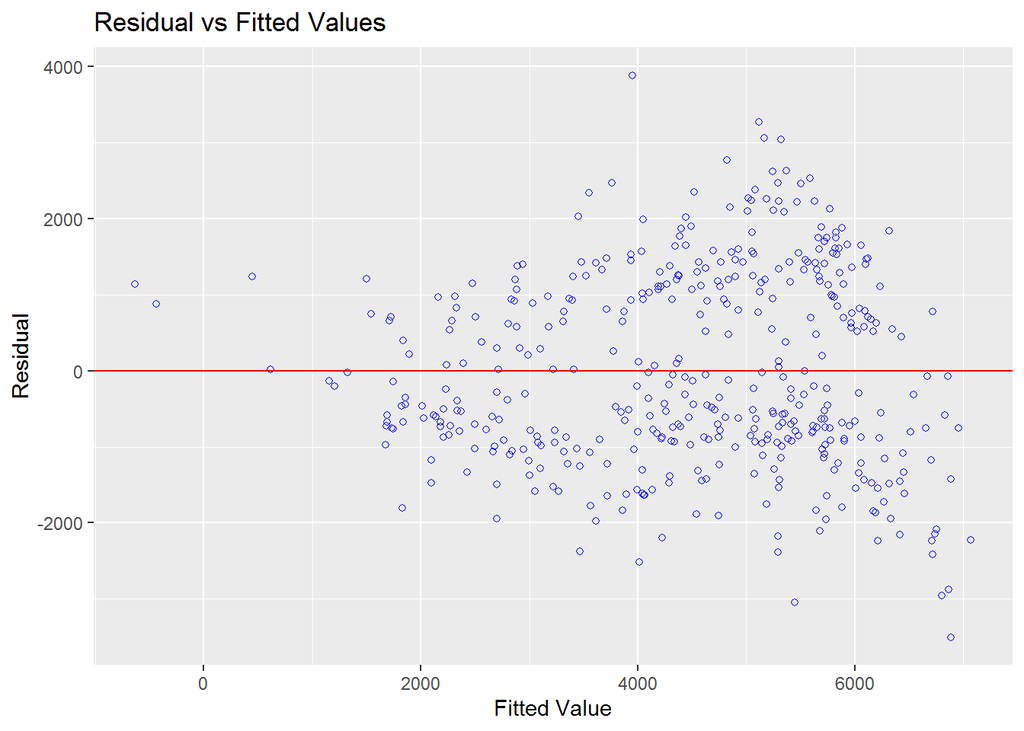

```r
olsrr::ols_plot_resid_fit(lm_mod_backward_p)
```

##### There is no pattern between fitted values and residuals, indicating that the model is stable

### Cook’s distances

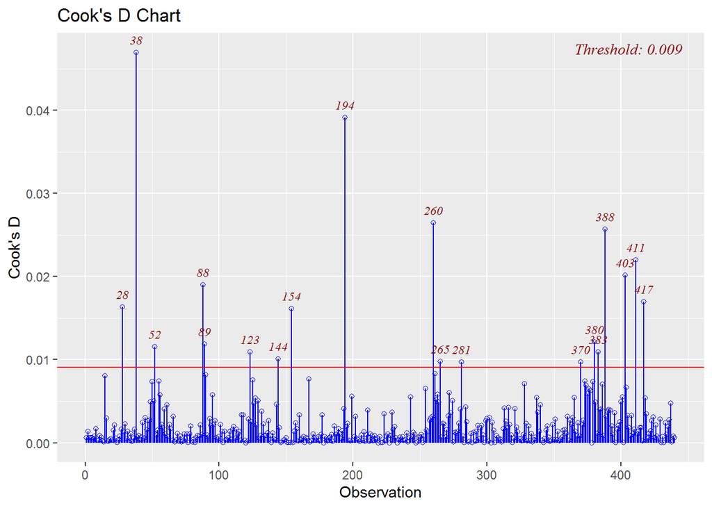

```r
ols_plot_cooksd_chart(lm_mod_backward_p)
```

```r
round(4/(nrow(train_set)-ncol(train_set)-1),3) #4/(N−k−1) <- formula for Cook's Distance Threshold
```

```
## [1] 0.009
```

##### A lot of observations exceeded the cook’s distance threshold and it should be scrutinized

```r
cooks_indexes <- which(cooks.distance(lm_mod_backward_p) > 0.009)
```

```r
cooks_indexes
```

```
##  50  69  90 150 151 203 249 266 328 442 448 472 612 631 641 647 668 682 692
##  28  38  52  88  89 123 144 154 194 260 265 281 370 380 383 388 403 411 417
```

### Summary of train data for the observations that exceeded cook’s distance threshold

```r
summary(train_set[cooks_indexes,5:9])
```

```
##   temperature       realfeel         humidity        windspeed
##  Min.   :40.30   Min.   : 33.80   Min.   :0.0000   Min.   : 2.200
##  1st Qu.:50.95   1st Qu.: 49.48   1st Qu.:0.5800   1st Qu.: 4.735
##  Median :63.28   Median : 64.41   Median :0.6900   Median : 6.970
##  Mean   :63.52   Mean   : 64.72   Mean   :0.6663   Mean   : 8.277
##  3rd Qu.:73.19   3rd Qu.: 75.99   3rd Qu.:0.8300   3rd Qu.:11.355
##  Max.   :89.37   Max.   :103.10   Max.   :0.9700   Max.   :21.130
##     rentals
##  Min.   :  22
##  1st Qu.:2040
##  Median :3982
##  Mean   :4097
##  3rd Qu.:6152
##  Max.   :8395
```

### Summary of train data for the observations that didn’t exceed cook’s distance threshold

```r
summary(train_set[-cooks_indexes,5:9])
```

```
##   temperature       realfeel        humidity        windspeed
##  Min.   :22.60   Min.   :12.59   Min.   :0.2800   Min.   : 0.930
##  1st Qu.:45.87   1st Qu.:42.42   1st Qu.:0.5100   1st Qu.: 5.850
##  Median :60.11   Median :61.32   Median :0.6200   Median : 7.660
##  Mean   :59.17   Mean   :59.05   Mean   :0.6228   Mean   : 7.991
##  3rd Qu.:73.01   3rd Qu.:75.43   3rd Qu.:0.7300   3rd Qu.: 9.630
##  Max.   :90.50   Max.   :98.82   Max.   :0.9700   Max.   :18.380
##     rentals
##  Min.   : 441
##  1st Qu.:3204
##  Median :4563
##  Mean   :4506
##  3rd Qu.:5905
##  Max.   :8227
```

##### The observations that exceeded the cook’s distance are essentially characterized by higher values of temperature, realfeel, humidity, windspeed but lower rentals (in terms of the average values)

### Third model - stepwise backward regression without influential observations

```r
lm_mod_backward_p_without_cooks_indexes <- lm(data=train_set[-cooks_indexes,],
                                              formula = rentals ~. -realfeel -weekday)
```

#### Summary

```r
summary(lm_mod_backward_p_without_cooks_indexes)
```

```
##
## Call:
## lm(formula = rentals ~ . - realfeel - weekday, data = train_set[-cooks_indexes,
##     ])
##
## Residuals:
##     Min      1Q  Median      3Q     Max
## -3028.1  -890.7  -271.6  1012.0  3105.9
##
## Coefficients:
##                             Estimate Std. Error t value Pr(>|t|)
## (Intercept)                 1775.373    559.024   3.176 0.001607 **
## seasonSummer                -611.957    197.547  -3.098 0.002084 **
## seasonFall                   586.704    184.538   3.179 0.001588 **
## seasonWinter                -594.117    221.370  -2.684 0.007573 **
## holidayYes                  -771.521    515.421  -1.497 0.135193
## weatherHeavy_precipitation -2207.614    501.899  -4.399 1.39e-05 ***
## weatherLight_precipitation  -270.420    162.945  -1.660 0.097762 .
## temperature                   83.336      7.104  11.731  < 2e-16 ***
## humidity                   -2314.647    608.999  -3.801 0.000166 ***
## windspeed                    -57.422     20.643  -2.782 0.005657 **
## ---
## Signif. codes:  0 '***' 0.001 '**' 0.01 '*' 0.05 '.' 0.1 ' ' 1
##
## Residual standard error: 1228 on 411 degrees of freedom
## Multiple R-squared:  0.5873, Adjusted R-squared:  0.5782
## F-statistic: 64.97 on 9 and 411 DF,  p-value: < 2.2e-16
```

##### holidayYes is not statistically significant after removing influential observations

#### Residual vs fitted values plot

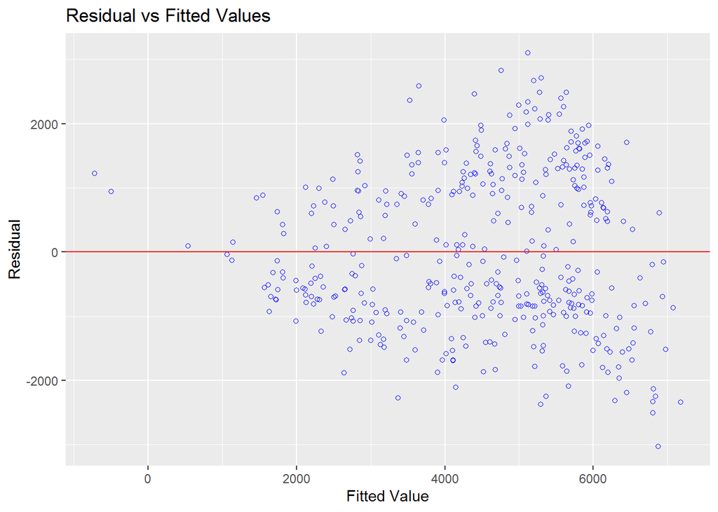

```r
olsrr::ols_plot_resid_fit(lm_mod_backward_p_without_cooks_indexes)
```

##### There is no pattern between fitted values and residuals

#### Variance inflation rate

```r
vif(lm_mod_backward_p_without_cooks_indexes)
```

```
##                 GVIF Df GVIF^(1/(2*Df))
## season      3.525097  3        1.233659
## holiday     1.041463  1        1.020521
## weather     1.888311  2        1.172245
## temperature 3.477321  1        1.864758
## humidity    1.947228  1        1.395431
## windspeed   1.157290  1        1.075774
```

##### None of the variables’ GVIF^(1/(2*Df)) exceeded 5.0

#### Durbin Watson test

```r
car::durbinWatsonTest(lm_mod_backward_p_without_cooks_indexes)
```

```
##  lag Autocorrelation D-W Statistic p-value
##    1       0.7162546     0.5657863       0
##  Alternative hypothesis: rho != 0
```

### Using the third model to predict test data

```r
test_predictions <- predict(lm_mod_backward_p_without_cooks_indexes, test_set)
```

#### MAE, MAPE, MSE metrics

```r
MLmetrics::MAE(test_predictions, test_set$rentals)
```

```
## [1] 1106.77
```

```r
MLmetrics::MAPE(test_predictions,test_set$rentals)
```

```
## [1] 0.3226188
```

```r
MLmetrics::MSE(test_predictions,test_set$rentals)
```

```
## [1] 1701716
```

##### The results indicate that the model didn’t perfom really well on the test set. The model was wrong by 1106.77 on average and it’s mean absolute percentage error was equal to 32.26%. It’s mean squared error amounted to 1701716.

##### As alternative to linear regression, random forest model was implemented to see if it can improve the above metrics

### Random forest regression model

#### Coding dummy variables

```r
train_dummies <-fastDummies::dummy_cols(train_set[,c(1:4)], remove_first_dummy = TRUE, remove_selected_columns = TRUE)

train_dummies <- cbind(train_dummies,train_set[,-c(1:4)])

test_dummies <- fastDummies::dummy_cols(test_set[,c(1:4)],remove_first_dummy = TRUE, remove_selected_columns = TRUE)

test_dummies <- cbind(test_dummies,test_set[,-c(1:4)])

train_dummies <- janitor::clean_names(train_dummies)
test_dummies <- janitor::clean_names(test_dummies)
```

```r
head(train_dummies)
```

```
##    season_summer season_fall season_winter holiday_yes weekday_tuesday
## 4              0           0             1           0               1
## 6              0           0             1           0               0
## 7              0           0             1           0               0
## 8              0           0             1           0               0
## 12             0           0             1           0               0
## 13             0           0             1           0               0
##    weekday_wednesday weekday_thursday weekday_friday weekday_saturday
## 4                  0                0              0                0
## 6                  0                1              0                0
## 7                  0                0              1                0
## 8                  0                0              0                1
## 12                 1                0              0                0
## 13                 0                1              0                0
##    weekday_sunday weather_heavy_precipitation weather_light_precipitation
## 4               0                           0                           0
## 6               0                           0                           0
## 7               0                           0                           1
## 8               0                           0                           1
## 12              0                           0                           0
## 13              0                           0                           0
##    temperature realfeel humidity windspeed rentals
## 4        34.52    28.40     0.59      6.67    1562
## 6        34.89    30.91     0.52      3.73    1606
## 7        34.23    28.01     0.50      7.02    1510
## 8        31.56    22.48     0.54     11.11     959
## 12       32.21    22.26     0.60     12.68    1162
## 13       31.56    21.12     0.47     12.53    1406
```

```r
head(test_dummies)
```

```
##    season_summer season_fall season_winter holiday_yes weekday_tuesday
## 1              0           0             1           0               0
## 2              0           0             1           0               0
## 3              0           0             1           0               0
## 5              0           0             1           0               0
## 9              0           0             1           0               0
## 10             0           0             1           0               0
##    weekday_wednesday weekday_thursday weekday_friday weekday_saturday
## 1                  0                0              0                1
## 2                  0                0              0                0
## 3                  0                0              0                0
## 5                  1                0              0                0
## 9                  0                0              0                0
## 10                 0                0              0                0
##    weekday_sunday weather_heavy_precipitation weather_light_precipitation
## 1               0                           0                           1
## 2               1                           0                           1
## 3               0                           0                           0
## 5               0                           0                           0
## 9               1                           0                           0
## 10              0                           0                           0
##    temperature realfeel humidity windspeed rentals
## 1        46.72    46.40     0.81      6.68     985
## 2        48.35    45.22     0.70     10.35     801
## 3        34.21    25.70     0.44     10.34    1349
## 5        36.80    30.44     0.44      7.78    1600
## 9        29.30    17.00     0.43     15.07     822
## 10       30.36    21.13     0.48      9.30    1321
```

#### Model formula

```r
rf_mod1 <- randomForest::randomForest(rentals ~. -realfeel -weekday_tuesday -weekday_wednesday -weekday_thursday -weekday_friday -weekday_saturday -weekday_sunday,
                                      ntree=200,
                                      importance=TRUE,
                                      data=train_dummies[-cooks_indexes,],
                                      mtry = 4)
```

```r
rf_mod1
```

```
##
## Call:
##  randomForest(formula = rentals ~ . - realfeel - weekday_tuesday -      weekday_wednesday - weekday_thursday - weekday_friday - weekday_saturday -      weekday_sunday, data = train_dummies[-cooks_indexes, ], ntree = 200,      importance = TRUE, mtry = 4)
##                Type of random forest: regression
##                      Number of trees: 200
## No. of variables tried at each split: 4
##
##           Mean of squared residuals: 1458373
##                     % Var explained: 59.13
```

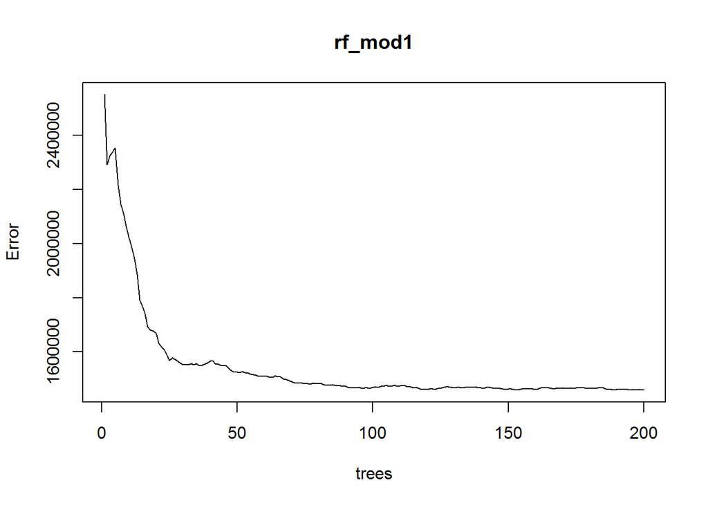

```r
plot(rf_mod1)
```

#### Variance importance plot

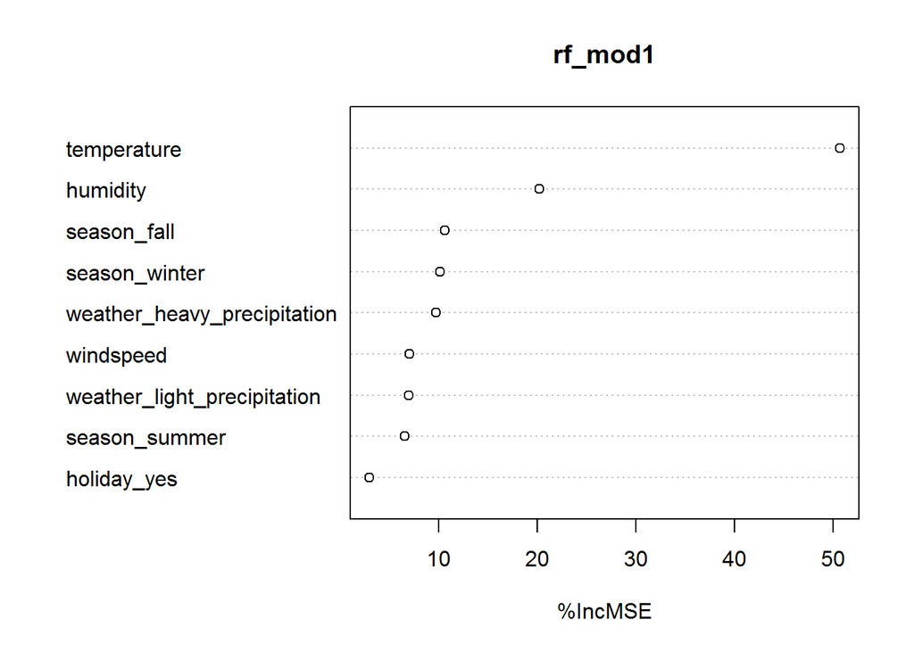

```r
varImpPlot(rf_mod1,type=1)
```

##### All of the variables are important because removing any variable would increase the MSE metric

#### MAE, MAPE and MSE metrics

```r
print(paste("MAE:",MLmetrics::MAE(y_pred = predict(rf_mod1,test_dummies),y_true = test_dummies$rentals)))
```

```
## [1] "MAE: 1052.07455188885"
```

```r
print(paste("MAPE:",MLmetrics::MAPE(y_pred=predict(rf_mod1,test_dummies),y_true=test_dummies$rentals)))
```

```
## [1] "MAPE: 0.322280050963389"
```

```r
print(paste("MSE:",MLmetrics::MSE(y_pred=predict(rf_mod1,test_dummies),y_true=test_dummies$rentals)))
```

```
## [1] "MSE: 1473719.50148693"
```

##### The values are slightly better than the third model (linear regression with stepwise backward regression and without influential observations)